# Venture Tutorial Part 3

Owain Evans (06.2013)

Jump to:

- Part 1: Tricky Coin
- Part 2: Gaussians.
- Part 3: Curve-fitting

## Curve-fitting with MRipl and map_proc

### 1. Quadratic Model, Plotting the Prior

In this notebook we implement 2D curve-fitting using Bayesian inference on a generative model for curves. We begin with a generative model for quadratic functions called `simple_quadratic`.

We model the x-values (the input variable for the curve `f`) as drawn from a fixed Gaussian:

```python
[assume x_d (lambda () (normal 0 5))]
```

We place independent Gaussian priors on the quadratic coefficients (`w0`,`w1`,`w2`) and a Gamma prior on the noise parameter `noise`. We then model the output y(x) as N( f(x), noise):

```python
[assume y_x (lambda (x) (normal (f x) noise) ) ]
```

Our initial aim is to learn the quadratic coefficients and not to learn the joint distribution on the x- and y-values. (We explicitly model the x-values to make sampling from the model easy. Here we fix the distribution to be `(normal 0 5)` but we can easily move to a model which learns this distribution).

(The variable `model_name` has no inferential role in the model and is used to provide titles for plots).

```python
from venture.venturemagics.ip_parallel import MRipl,mk_p_ripl,venture
from venture.venturemagics.reg_demo_utils import *
ripl=mk_p_ripl()
```

```python
%%venture ripl
[assume x_d (lambda () (normal 0 5))]

[assume w0 (normal 0 3) ]
[assume w1 (normal 0 1) ]
[assume w2 (normal 0 .3) ]
[assume f (lambda (x) (+ w0 (* w1 x) (* w2 (* x x)) ) ) ]

[assume noise (gamma 2 1) ]
[assume y_x (lambda (x) (normal (f x) noise) ) ]

[assume model_name (quote simple_quadratic)]
```

[output not shown]

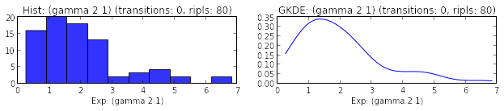

```python
visualize_prior=MRipl(80,local_mode=True)
out = visualize_prior.snapshot('(gamma 2 1)',plot=True)
```

```python
ripl.print_directives()
```

[output not shown]

Having defined our generative model we want to visualize our prior on curves. For the Tricky Coin and Gaussian parts of this tutorial we used simple plots that are built into the `snapshot` method. For curve-fitting (and for almost any other use of Venture) we need to make custom plots.

We use a plotting function `plot_conditional` (defined in the module `reg_demo_utils`) to display the RIPL's current value for the curve `f` and for the conditional distribution. The conditional distribution is `(y_x <x_value>)` in the Venture program and
$$P(y(X) | x= X )$$ in mathematical notation. This is the distribution on possible values for $y(X)$ for each $X$ in a grid of x-values.

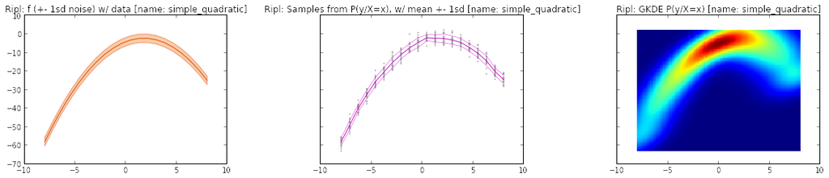

```python
out=plot_conditional(ripl, x_range=(-8,8), number_xs=20, number_reps=20)
```

The left plot shows the curve `f` with 1SD noise intervals (from `noise`). The middle plot samples from `(y_x <x_value>)` over a grid of x-values and displays each y-value along with means and 1SD curves. The right plot is a heatmap of the samples from the middle plot.

This kind of plotting function does not depend on the functional form of `f`. Values are generated by repeatedly sampling `(f <x_value>)` and `(y_x <x_value>)` on a grid of x-values. The function `my_plot_conditional` below is a simpler version of `plot_conditional`.

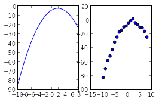

```python
def my_plot_conditional(ripl,x_range=(-8,8),number_xs=30):
    xr = np.linspace(x_range[0],x_range[1],number_xs)
    f_xr = [ripl.sample('(f %f)' %x) for x in xr ]
    y_xr = [ripl.sample('(y_x %f)' %x) for x in xr ]

    fig,ax = plt.subplots(1,2,figsize=(4,2.5))
    ax[0].plot(xr,f_xr) ## ax[0].plot(xr,f_l,xr,f_u)
    ax[1].scatter(xr,y_xr) ##ax[1].plot(xr,y_mean,xr,y_l,xr,y_u)
    return xr,f_xr

out = my_plot_conditional(ripl,(-10,8),20)
```

We could also display `f` and `y_x` using the quadratic functional form and sampling the relevant parameters from the model:

```python
print 'f(x) = %.2f + %.2fx + %.2fx^2' % (ripl.sample('w0'),ripl.sample('w1'),ripl.sample('w2'))
print 'y = N( f(x), %.2f)' % ripl.sample('noise')
```

[output not shown]

## 2. Conditioning the model on data

We generate some $(x,y)$ pairs from a curve $f$ and then condition the model on them. Though we could generate data from the Venture program itself, we use Python for convenience.

We generate x-values as a mixture of two Gaussians. The curve is $f(x)=-2x$, and $y \sim N(f(x),0.6)$.

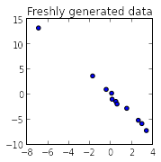

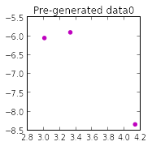

```python
# generate x values
xs=list(np.random.normal(3,.7,3)) + list(np.random.normal(-1,1.4,8))

# specify f and y_x
f = lambda x:-2*x
y_x = lambda x: np.random.normal(f(x),.6)

# compute y values from x and f(x)
ys = [y_x(x) for x in xs]

# store values as variable 'data'
data = zip(xs,ys)

# split the data set in two
data0,data1 = data[:6],data[6:]

# plot (x,y) pairs
fig,ax = plt.subplots(figsize=(2.5,2.5))
[ax.scatter( *zip(*data_i) ) for data_i in (data0,data1)];
ax.set_title('Freshly generated data')

# pre-generated data
data0 = ([ 4.13, -8.34],
         [ 3.01, -6.05],
         [ 3.33, -5.9 ],)

# plot pre-generated data
fig,ax = plt.subplots(figsize=(2.5,2.5))
ax.scatter( *zip(*data0) , color='m')
ax.set_title('Pre-generated data0');
```

We condition the model on the $(x,y)$ pairs from `data0`. We then run our default MH inference program. We compare the prior and posterior conditionals on a grid of points given by `x_range`. Since the data is generated by a quadratic $f(x) = -2x$ with parameters that are plausible given our prior, we expect inference to find a curve that fits the points well.

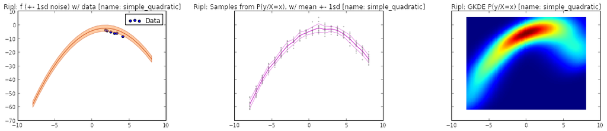

```python
# plot prior conditional (before conditioning)
prior=plot_conditional(ripl,data=data0,x_range=(-8,8),number_xs=20,number_reps=15)
```

```python
# condition model on x,y pairs
for (x,y) in data0:
    ripl.observe('(y_x %f)' % x , '%f' % y )

ripl.print_directives('observe')
```

```
9: [ observe (y_x 4.130000) -8.340000 ]
10: [ observe (y_x 3.010000) -6.050000 ]
11: [ observe (y_x 3.330000) -5.900000 ]
```

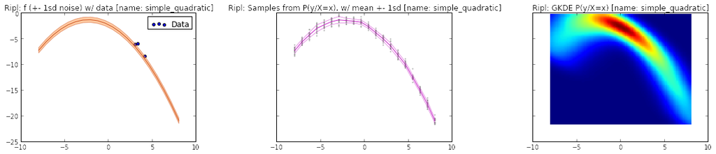

```python
# Plot posterior conditional (after inference)
ripl.infer(50)
out=plot_conditional(ripl,data=data0, x_range=(-8,8), number_xs=20, number_reps=20)
```

### 3. Curve-fitting with MRipl

For convenience, we load the MRipl with a string, `simple_quadratic_model` (stored in `reg_demo_utils`) and we use a function `observe_xy` that loops over the $(x,y)$ points in `data0` and adds `observe` directives to the MRipl.

```python
from venture.venturemagics.ip_parallel import MRipl,mk_p_ripl,venture
from venture.venturemagics.reg_demo_utils import *

data0 = ([ 4.13, -8.34],
         [ 3.01, -6.05],
         [ 3.33, -5.9 ],
         [ 2.5,  -5.05],
         [ 2.01,  -4.2],
         [ 1.8,   -3.72],)

v=MRipl(20, local_mode=True)
out = v.execute_program(simple_quadratic_model);
print simple_quadratic_model

out = observe_xy(v,data0);
print 'data0: ', data0
```

```
[assume w0 (normal 0 3) ]
[assume w1 (normal 0 1) ]
[assume w2 (normal 0 .3) ]
[assume x (mem (lambda (i) (x_d) ) )]
[assume x_d (lambda () (normal 0 5))]
[assume noise (gamma 2 1) ]
[assume f (lambda (x) (+ w0 (* w1 x) (* w2 (* x x)) ) ) ]
[assume y_x (lambda (x) (normal (f x) noise) ) ]
[assume y (mem (lambda (i) (y_x (x i)) ) )]
[assume model_name (quote simple_quadratic)]

data0:  ([4.13, -8.34], [3.01, -6.05], [3.33, -5.9], [2.5, -5.05], [2.01, -4.2], [1.8, -3.72])
```

Though we have 'observed' the points `data0`, we have not yet run `infer` and so the MRipl is still in its prior state. We visualize this state by mapping our single-ripl plotting functions across all ripls in the MRipl. We use the MRipl method `map_proc` which has the form:

```python
<mripl>.map_proc( no_ripls, proc, *proc_args, **proc_kwargs)
```

We select how many ripls to map over with `no_ripls` or map across all ripls by setting the first positional argument to `'all'`. The argument `proc` is a procedure with a ripl as its first argument. If the procedure has other arguments we enter them in `proc_args` and `proc_kwargs`. (Side-note: If using MRipl with IPython Parallel, the procedure needs to be serializable. We use the `interactive` decorator to change the `__module__` of `proc` to `__main__`.)

```python
def sample_params(r):
    return (r.sample('w0'),r.sample('w1'),r.sample('w2')), r.sample('noise')

outs = v.map_proc(3,sample_params)
for w,noise in outs:
    print 'f(x) = %.2f + %.2fx + %.2fx^2' % w, '    y = N(f(x),%.2f)' % noise
    print '-----'
```

```
f(x) = 0.40 + -0.09x + 0.50x^2     y = N(f(x),0.56)
-----
f(x) = 0.92 + -0.42x + -0.06x^2     y = N(f(x),2.11)
-----
f(x) = -3.91 + 0.64x + -0.20x^2     y = N(f(x),0.73)
-----
```

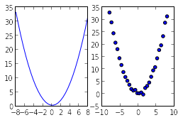

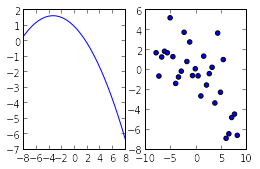

```python
# mapping a plotting function across ripls
out = v.map_proc(2,my_plot_conditional)
```

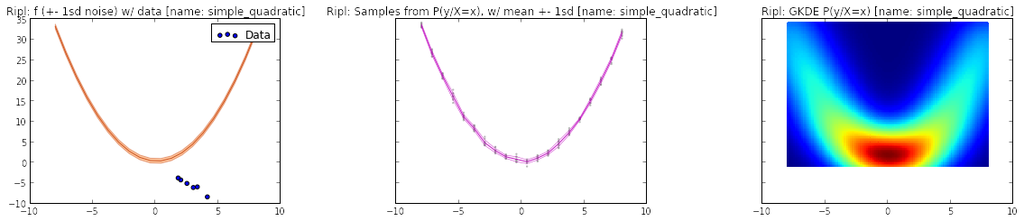

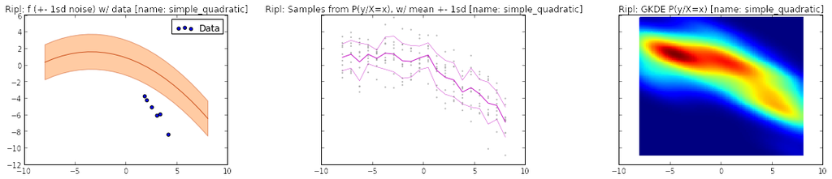

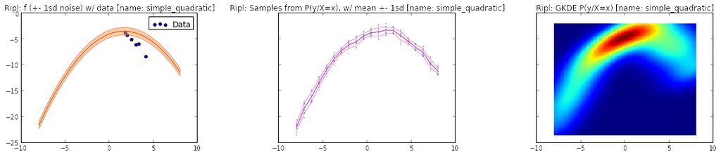

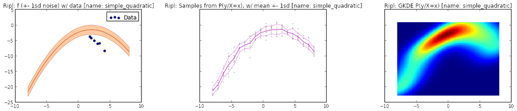

```python
# visualize sample curves from our prior via plot_conditional
out=v.map_proc(4,plot_conditional,data=data0,x_range=(-8,8),number_xs=20,number_reps=10)
```

As noted above, it's not straightforward with a single ripl to visualize our Bayesian uncertainty over different curves `f` and conditional distributions `y_x`. With an MRipl, we use a plotting function `predictive` that samples `(y_x <x_value>)` on a grid of x-values for each ripl in the MRipl.

The plots below show our prior uncertainty. We then run inference and visualize the posterior conditional and posterior predictive.

[figure not shown]

```python
out=predictive(v,data=data0,x_range=(-8,8),number_xs=30,number_reps=15)

# note that because the prior on the quadratic parameters are Normal distributions
# symmetric about 0, our predictive distribution is symmetric
```

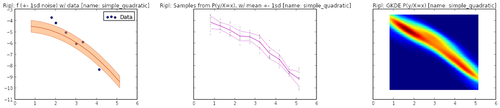

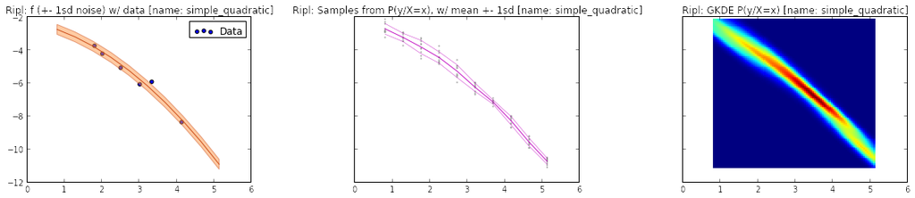

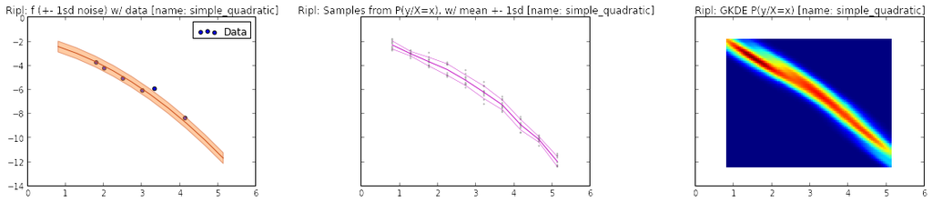

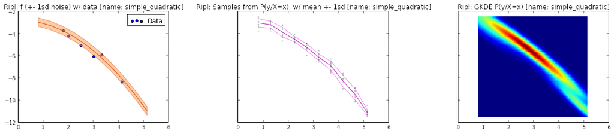

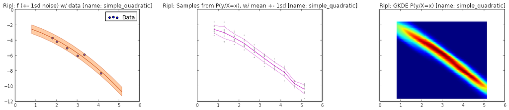

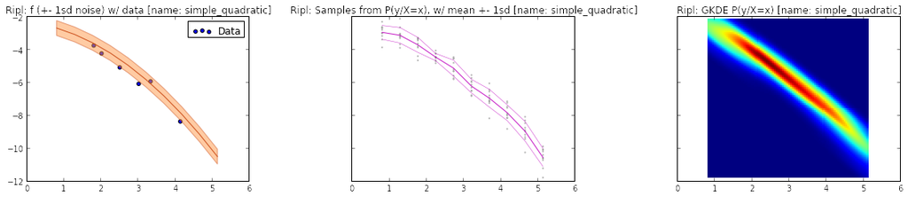

```python
# run inference on the MRipl on *data0*
v.infer(500)
out=v.map_proc(6, plot_conditional,data=data0,number_xs=10,number_reps=10)
```

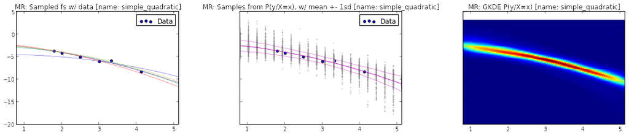

```python
out = predictive(v,data=data0, number_xs=20,number_reps=30)
```

## Fourier Model

### 1. Prior and Posterior on Data

We can easily adjust the functional form of the curves in the generative model. We move from quadratics to the form: $$f(x) = w_0 + w_1 \sin(\omega x + \theta)$$ The conditional distribution is still: $$y(x) = N( f(x), noise)$$

```python
from venture.venturemagics.ip_parallel import MRipl,display_directives,mk_p_ripl,venture
from venture.venturemagics.reg_demo_utils import *
data0 = ([ 4.13, -8.34],
         [ 3.01, -6.05],
         [ 3.33, -5.9 ],
         [-3.07,  6.22],
         [-0.53,  0.92],
         [-1.57,  2.96],)

print simple_fourier_model
```

```
[assume w0 (normal 0 3) ]
[assume w1 (normal 0 3) ]
[assume omega (normal 0 3) ]
[assume theta (normal 0 3) ]
[assume x (mem (lambda (i) (x_d) ) )]
[assume x_d (lambda () (normal 0 5))]
[assume noise (gamma 2 1) ]
[assume f (lambda (x) (+ w0 (* w1 (sin (+ (* omega x) theta) ) ) ) ) ]
[assume y_x (lambda (x) (normal (f x) noise) ) ]
[assume y (mem (lambda (i) (y_x (x i))  ))]
[assume model_name (quote simple_fourier)]
```

We condition on the same dataset as above and run inference on the Fourier model. Recall from above that `data0` was generated using $y=-2x$. We can compare the logscores of the two models.

```python
vf = MRipl(10)
vf.execute_program(simple_fourier_model)
observe_xy(vf,data=data0)
vf.infer(1000)
out = vf.map_proc(4, plot_conditional, data=data0, number_xs=20, number_reps=10)
```

[output not shown]

```python
vs = [v,vf]
[display_logscores(r) for r in vs];
# display_logscores function in *reg_demo_utils* prints the mean and max logscore across ripls
# it uses the *ripl* method *get_global_logscore*
```

[output not shown]

### 2. Model Selection and the Quadratic-Fourier Model

The examples above illustrate model comparison using multiple MRipls. We can condition models on the same data and make qualitative comparisons via plots and quantative comparisons via the `get_global_logscore` method or from statistics specialized for a given model (e.g MSE for curve-fitting).

Venture also makes it easy to combine models. For curve-fitting we simply add a prior on the functional form. This enables us to do Bayesian model selection over the `simple_quadratic` and `simple_fourier` models above.

We also expand on the models above by adding a hyper-prior over the prior on the x-values. By learning the marginal $P(x)$ as well as the conditional $P(y|x)$ we can answer a wider range of queries about the joint $P(x,y)$. In the `quad_fourier` model below, we model the x-values as follows: $$ x \sim student(\nu)$$

$$ \nu \sim gamma(10,1)$$

```python
from venture.venturemagics.ip_parallel import MRipl,display_directives,mk_p_ripl,venture
from venture.venturemagics.reg_demo_utils import *
data0 = ([ 4.13, -8.34],
         [ 3.01, -6.05],
         [ 3.33, -5.9 ],
         [-3.07,  6.22],
         [-0.53,  0.92],
         [-1.57,  2.96],)

quad_fourier =  x_model_t + quad_fourier_model
print quad_fourier
```

```
[assume nu (gamma 10 1)]
[assume x_d (lambda () (student_t nu) ) ]
[assume x (mem (lambda (i) (x_d) ) )]

[assume w0 (normal 0 3) ]
[assume w1 (normal 0 2.5) ]
[assume w2 (normal 0 .3) ]
[assume omega (normal 0 3) ]
[assume theta (normal 0 3) ]

[assume noise (gamma 2 1) ]

[assume model (if (flip) 1 0) ]
[assume quadratic (lambda (x) (+ w0 (* w1 x) (* w2 (* x x) ) ) ) ]
[assume fourier (lambda (x) (+ w0 (* w1 (sin (+ (* omega x) theta) ) ) ) ) ]
[assume f (if (= model 0) quadratic fourier) ]

[assume y_x (lambda (x) (normal (f x) noise) ) ]
[assume y (mem (lambda (i) (y_x (x i))  ))]
[assume model_name (quote quad_fourier)]
```

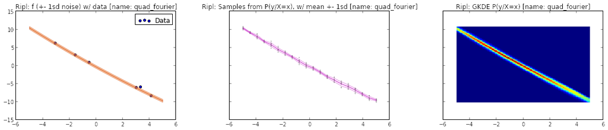

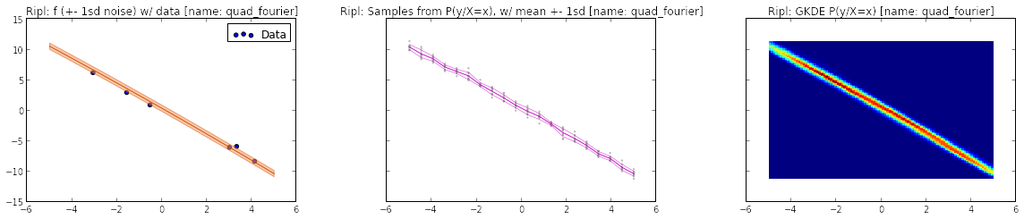

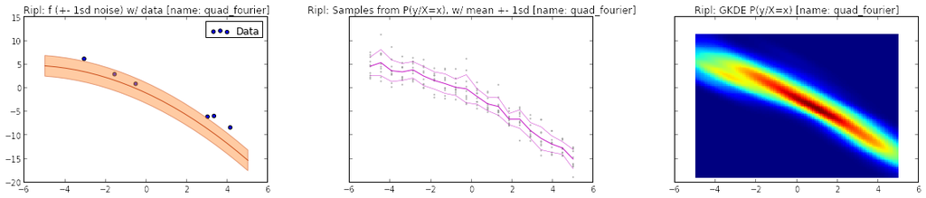

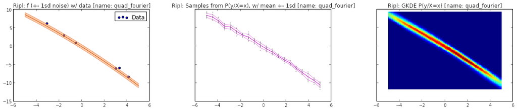

```python
v = MRipl(10, local_mode = True)
v.execute_program( quad_fourier )
observe_xy(v, data=data0)
v.infer(1000)
out=v.map_proc(4, plot_conditional,data=data0,x_range=(-5,5),number_xs=20, number_reps=10)
```

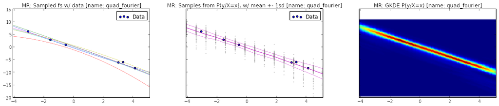

```python
out=predictive(v,data=data0,x_range=(-6,6),number_xs=15,number_reps=20)
```

```python
# model selection
fourier_prob = np.mean( v.sample('model') )
print 'Inferred model probability: quadratic %.2f, fourier %.2f \n' % (1-fourier_prob,fourier_prob)


# parameter inference
no_sample_ripls = 3
print '\nSampled parameters for %i ripls in MRipl:'% no_sample_ripls

def sample_params(r): return tuple( map(r.sample,('w0','w1','w2','noise')) )

for params in v.map_proc(no_sample_ripls,sample_params):
    print 'f(x) = %.2f + %.2fx + %.2fx^2     y = N(f(x),%.2f) \n---\n' % params

print 'Mean parameter values:\n'
mean_params = tuple( np.mean(sample_params(v),axis=1) )
print 'f(x) = %.2f + %.2fx + %.2fx^2     y = N(f(x),%.2f)' % mean_params
```

```
Inferred model probability: quadratic 1.00, fourier 0.00


Sampled parameters for 3 ripls in MRipl:
f(x) = -0.37 + -2.02x + 0.03x^2     y = N(f(x),0.40)
---

f(x) = 0.37 + -2.09x + -0.01x^2     y = N(f(x),0.51)
---

f(x) = -1.06 + -2.00x + -0.17x^2     y = N(f(x),2.19)
---

Mean parameter values:

f(x) = -0.14 + -1.95x + -0.02x^2     y = N(f(x),0.72)
```